# Final_Project_SantiagoGutierrez

Santiago Gutierrez

2023-12-10

# 490 Final Project

The goal of this project is to construct a model to predict whether a packet of network traffic is anomalous or not (normal).

This dataset has nine types of attacks, namely, Fuzzers, Analysis, Backdoors, DoS, Exploits, Generic, Reconnaissance, Shellcode and Worms.

## Training data set

```r
# Set working directory (optional, if you want to work from a specific location)
setwd("C:/Users/sangu/Downloads")

# Training data set
trainingDataset <- read_csv("C:/Users/sangu/Downloads/UNSW_NB15_training-set.csv")
head(trainingDataset)
```

```
## # A tibble: 6 × 45
##      id   dur proto service state spkts dpkts sbytes dbytes  rate  sttl  dttl
##   <dbl> <dbl> <chr> <chr>   <chr> <dbl> <dbl>  <dbl>  <dbl> <dbl> <dbl> <dbl>
## 1     1 0.121 tcp   -       FIN       6     4    258    172  74.1   252   254
## 2     2 0.650 tcp   -       FIN      14    38    734  42014  78.5    62   252
## 3     3 1.62  tcp   -       FIN       8    16    364  13186  14.2    62   252
## 4     4 1.68  tcp   ftp     FIN      12    12    628    770  13.7    62   252
## 5     5 0.449 tcp   -       FIN      10     6    534    268  33.4   254   252
## 6     6 0.381 tcp   -       FIN      10     6    534    268  39.4   254   252
## # ℹ 33 more variables: sload <dbl>, dload <dbl>, sloss <dbl>, dloss <dbl>,
## #   sinpkt <dbl>, dinpkt <dbl>, sjit <dbl>, djit <dbl>, swin <dbl>,
## #   stcpb <dbl>, dtcpb <dbl>, dwin <dbl>, tcprtt <dbl>, synack <dbl>,
## #   ackdat <dbl>, smean <dbl>, dmean <dbl>, trans_depth <dbl>,
## #   response_body_len <dbl>, ct_srv_src <dbl>, ct_state_ttl <dbl>,
## #   ct_dst_ltm <dbl>, ct_src_dport_ltm <dbl>, ct_dst_sport_ltm <dbl>,
## #   ct_dst_src_ltm <dbl>, is_ftp_login <dbl>, ct_ftp_cmd <dbl>, …
```

```r
summary(trainingDataset)
```

```
##        id              dur              proto             service
##  Min.   :     1   Min.   : 0.00000   Length:175341      Length:175341
##  1st Qu.: 43836   1st Qu.: 0.00001   Class :character   Class :character
##  Median : 87671   Median : 0.00158   Mode  :character   Mode  :character
##  Mean   : 87671   Mean   : 1.35939
##  3rd Qu.:131506   3rd Qu.: 0.66807
##  Max.   :175341   Max.   :59.99999
##     state               spkts            dpkts              sbytes
##  Length:175341      Min.   :   1.0   Min.   :    0.00   Min.   :      28
##  Class :character   1st Qu.:   2.0   1st Qu.:    0.00   1st Qu.:     114
##  Mode  :character   Median :   2.0   Median :    2.00   Median :     430
##                     Mean   :  20.3   Mean   :   18.97   Mean   :    8845
##                     3rd Qu.:  12.0   3rd Qu.:   10.00   3rd Qu.:    1418
##                     Max.   :9616.0   Max.   :10974.00   Max.   :12965233
##      dbytes              rate                sttl            dttl
##  Min.   :       0   Min.   :      0.0   Min.   :  0.0   Min.   :  0.00
##  1st Qu.:       0   1st Qu.:     32.8   1st Qu.: 62.0   1st Qu.:  0.00
##  Median :     164   Median :   3225.8   Median :254.0   Median : 29.00
##  Mean   :   14929   Mean   :  95406.2   Mean   :179.5   Mean   : 79.61
##  3rd Qu.:    1102   3rd Qu.: 125000.0   3rd Qu.:254.0   3rd Qu.:252.00
##  Max.   :14655550   Max.   :1000000.0   Max.   :255.0   Max.   :254.00
##      sload               dload              sloss              dloss
##  Min.   :0.000e+00   Min.   :       0   Min.   :   0.000   Min.   :   0.000
##  1st Qu.:1.305e+04   1st Qu.:       0   1st Qu.:   0.000   1st Qu.:   0.000
##  Median :8.797e+05   Median :    1447   Median :   0.000   Median :   0.000
##  Mean   :7.345e+07   Mean   :  671206   Mean   :   4.953   Mean   :   6.948
##  3rd Qu.:8.889e+07   3rd Qu.:   27845   3rd Qu.:   3.000   3rd Qu.:   2.000
##  Max.   :5.988e+09   Max.   :22422730   Max.   :4803.000   Max.   :5484.000
##      sinpkt             dinpkt              sjit              djit
##  Min.   :    0.00   Min.   :    0.00   Min.   :      0   Min.   :     0.0
##  1st Qu.:    0.01   1st Qu.:    0.00   1st Qu.:      0   1st Qu.:     0.0
##  Median :    0.28   Median :    0.01   Median :      0   Median :     0.0
##  Mean   :  985.98   Mean   :   88.22   Mean   :   4976   Mean   :   604.4
##  3rd Qu.:   55.16   3rd Qu.:   51.05   3rd Qu.:   2513   3rd Qu.:   115.0
##  Max.   :84371.50   Max.   :56716.82   Max.   :1460480   Max.   :289388.3
##       swin           stcpb               dtcpb                dwin
##  Min.   :  0.0   Min.   :0.000e+00   Min.   :0.000e+00   Min.   :  0
##  1st Qu.:  0.0   1st Qu.:0.000e+00   1st Qu.:0.000e+00   1st Qu.:  0
##  Median :  0.0   Median :0.000e+00   Median :0.000e+00   Median :  0
##  Mean   :116.3   Mean   :9.693e+08   Mean   :9.689e+08   Mean   :115
```

[output cut: 29 more lines]

```
##  Max.   :65.00   Max.   :4.00000   Max.   :4.00000   Max.   :30.0000
##    ct_src_ltm       ct_srv_dst     is_sm_ips_ports    attack_cat
##  Min.   : 1.000   Min.   : 1.000   Min.   :0.00000   Length:175341
##  1st Qu.: 2.000   1st Qu.: 2.000   1st Qu.:0.00000   Class :character
##  Median : 3.000   Median : 4.000   Median :0.00000   Mode  :character
##  Mean   : 6.956   Mean   : 9.101   Mean   :0.01575
##  3rd Qu.: 9.000   3rd Qu.:12.000   3rd Qu.:0.00000
##  Max.   :60.000   Max.   :62.000   Max.   :1.00000
##      label
##  Min.   :0.0000
##  1st Qu.:0.0000
##  Median :1.0000
##  Mean   :0.6806
##  3rd Qu.:1.0000
##  Max.   :1.0000
```

```r
#str(trainingDataset)

show_col_types = FALSE
```

## Testing data set

```r
# Testing data set
testingDataset <- read_csv("C:/Users/sangu/Downloads/UNSW_NB15_testing-set.csv")
head(testingDataset)
```

```
## # A tibble: 6 × 45
##      id     dur proto service state spkts dpkts sbytes dbytes   rate  sttl  dttl
##   <dbl>   <dbl> <chr> <chr>   <chr> <dbl> <dbl>  <dbl>  <dbl>  <dbl> <dbl> <dbl>
## 1     1 1.10e-5 udp   -       INT       2     0    496      0 9.09e4   254     0
## 2     2 8   e-6 udp   -       INT       2     0   1762      0 1.25e5   254     0
## 3     3 5   e-6 udp   -       INT       2     0   1068      0 2.00e5   254     0
## 4     4 6   e-6 udp   -       INT       2     0    900      0 1.67e5   254     0
## 5     5 1   e-5 udp   -       INT       2     0   2126      0 1.00e5   254     0
## 6     6 3   e-6 udp   -       INT       2     0    784      0 3.33e5   254     0
## # ℹ 33 more variables: sload <dbl>, dload <dbl>, sloss <dbl>, dloss <dbl>,
## #   sinpkt <dbl>, dinpkt <dbl>, sjit <dbl>, djit <dbl>, swin <dbl>,
## #   stcpb <dbl>, dtcpb <dbl>, dwin <dbl>, tcprtt <dbl>, synack <dbl>,
## #   ackdat <dbl>, smean <dbl>, dmean <dbl>, trans_depth <dbl>,
## #   response_body_len <dbl>, ct_srv_src <dbl>, ct_state_ttl <dbl>,
## #   ct_dst_ltm <dbl>, ct_src_dport_ltm <dbl>, ct_dst_sport_ltm <dbl>,
## #   ct_dst_src_ltm <dbl>, is_ftp_login <dbl>, ct_ftp_cmd <dbl>, …
```

```r
summary(testingDataset)
```

```
##        id             dur              proto             service
##  Min.   :    1   Min.   : 0.00000   Length:82332       Length:82332
##  1st Qu.:20584   1st Qu.: 0.00001   Class :character   Class :character
##  Median :41167   Median : 0.01414   Mode  :character   Mode  :character
##  Mean   :41167   Mean   : 1.00676
##  3rd Qu.:61749   3rd Qu.: 0.71936
##  Max.   :82332   Max.   :59.99999
##     state               spkts              dpkts              sbytes
##  Length:82332       Min.   :    1.00   Min.   :    0.00   Min.   :      24
##  Class :character   1st Qu.:    2.00   1st Qu.:    0.00   1st Qu.:     114
##  Mode  :character   Median :    6.00   Median :    2.00   Median :     534
##                     Mean   :   18.67   Mean   :   17.55   Mean   :    7994
##                     3rd Qu.:   12.00   3rd Qu.:   10.00   3rd Qu.:    1280
##                     Max.   :10646.00   Max.   :11018.00   Max.   :14355774
##      dbytes              rate                sttl          dttl
##  Min.   :       0   Min.   :      0.0   Min.   :  0   Min.   :  0.00
##  1st Qu.:       0   1st Qu.:     28.6   1st Qu.: 62   1st Qu.:  0.00
##  Median :     178   Median :   2650.2   Median :254   Median : 29.00
##  Mean   :   13234   Mean   :  82410.9   Mean   :181   Mean   : 95.71
##  3rd Qu.:     956   3rd Qu.: 111111.1   3rd Qu.:254   3rd Qu.:252.00
##  Max.   :14657531   Max.   :1000000.0   Max.   :255   Max.   :253.00
##      sload               dload              sloss              dloss
##  Min.   :0.000e+00   Min.   :       0   Min.   :   0.000   Min.   :   0.000
##  1st Qu.:1.120e+04   1st Qu.:       0   1st Qu.:   0.000   1st Qu.:   0.000
##  Median :5.770e+05   Median :    2113   Median :   1.000   Median :   0.000
##  Mean   :6.455e+07   Mean   :  630547   Mean   :   4.754   Mean   :   6.309
##  3rd Qu.:6.514e+07   3rd Qu.:   15858   3rd Qu.:   3.000   3rd Qu.:   2.000
##  Max.   :5.268e+09   Max.   :20821108   Max.   :5319.000   Max.   :5507.000
##      sinpkt             dinpkt              sjit                djit
##  Min.   :    0.00   Min.   :    0.00   Min.   :      0.0   Min.   :     0.0
##  1st Qu.:    0.01   1st Qu.:    0.00   1st Qu.:      0.0   1st Qu.:     0.0
##  Median :    0.56   Median :    0.01   Median :     17.6   Median :     0.0
##  Mean   :  755.39   Mean   :  121.70   Mean   :   6363.1   Mean   :   535.2
##  3rd Qu.:   63.41   3rd Qu.:   63.14   3rd Qu.:   3219.3   3rd Qu.:   128.5
##  Max.   :60009.99   Max.   :57739.24   Max.   :1483830.9   Max.   :463199.2
##       swin           stcpb               dtcpb                dwin
##  Min.   :  0.0   Min.   :0.000e+00   Min.   :0.000e+00   Min.   :  0.0
##  1st Qu.:  0.0   1st Qu.:0.000e+00   1st Qu.:0.000e+00   1st Qu.:  0.0
##  Median :255.0   Median :2.789e+07   Median :2.857e+07   Median :255.0
##  Mean   :133.5   Mean   :1.085e+09   Mean   :1.073e+09   Mean   :128.3
```

[output cut: 29 more lines]

```
##  Max.   :63.000   Max.   :2.000000   Max.   :2.000000   Max.   :16.0000
##    ct_src_ltm       ct_srv_dst     is_sm_ips_ports    attack_cat
##  Min.   : 1.000   Min.   : 1.000   Min.   :0.00000   Length:82332
##  1st Qu.: 1.000   1st Qu.: 2.000   1st Qu.:0.00000   Class :character
##  Median : 3.000   Median : 5.000   Median :0.00000   Mode  :character
##  Mean   : 6.468   Mean   : 9.164   Mean   :0.01113
##  3rd Qu.: 7.000   3rd Qu.:11.000   3rd Qu.:0.00000
##  Max.   :60.000   Max.   :62.000   Max.   :1.00000
##      label
##  Min.   :0.0000
##  1st Qu.:0.0000
##  Median :1.0000
##  Mean   :0.5506
##  3rd Qu.:1.0000
##  Max.   :1.0000
```

```r
#str(testingDataset)
show_col_types = FALSE
```

## “attack_cat” and “label”

We will be using “label” and ignoring “attack_cat”. Notice that “label” is 0 for normal traffic and 1 for anomalous traffic.

## Training table “label”

```r
table(trainingDataset$label)
```

```
##
##      0      1
##  56000 119341
```

```r
label_table <- table(trainingDataset$label)

total_rows <- sum(label_table)

percentage_0 <- (label_table[1] / total_rows) * 100
percentage_1 <- (label_table[2] / total_rows) * 100

percentage_0 #percentage of 0s on the training data set
```

```
##        0
## 31.93777
```

```r
percentage_1 #percentage of 1s on the training data set
```

```
##        1
## 68.06223
```

## Testing table “label”

```r
table(testingDataset$label)
```

```
##
##     0     1
## 37000 45332
```

```r
label_table <- table(testingDataset$label)

total_rows <- sum(label_table)

percentage_0 <- (label_table[1] / total_rows) * 100
percentage_1 <- (label_table[2] / total_rows) * 100

percentage_0 #percentage of 0s on the testing data set
```

```
##     0
## 44.94
```

```r
percentage_1 #percentage of 1s on the testing data set
```

```
##     1
## 55.06
```

#### Proportion of 0s in the testing data set is 44.94% and in the training data set is 31.93%

#### Proportion of 1s in the testing data set is 55.06% and in the training data set is 68.06%

# First model

### First model using rate + dpkts + sbytes + dbytes + sqrt(dur) + state + service

```r
# 1st regression model
glm.fit <- glm(label ~ rate + dpkts + sbytes + dbytes + sqrt(dur) + state + service,
               data = trainingDataset, family = binomial)
glm.probs <- predict(glm.fit, trainingDataset, type = "response")

# Convert predicted probabilities to binary predictions (0 or 1)
glm.pred <- ifelse(glm.probs > 0.5, 1, 0)
```

### Predicted probabilities for the first 10

```r
# Display or use the predicted probabilities for the first 10 observations
print(glm.probs[1:10])
```

```
##         1         2         3         4         5         6         7         8
## 0.5564793 0.5575846 0.7036646 0.8728776 0.5909961 0.5782448 0.5780329 0.5597507
##         9        10
## 0.5632806 0.5521678
```

### Checking the accuracy of the model using the mean of the predictions

## Accuracy of 53.53%

```r
# Calculate accuracy (mean of correct predictions)
accuracy <- mean(glm.pred == testingDataset$label)
print(accuracy)
```

```
## [1] 0.5353625
```

### Ploting the model created in comparision with the smean of the data base.

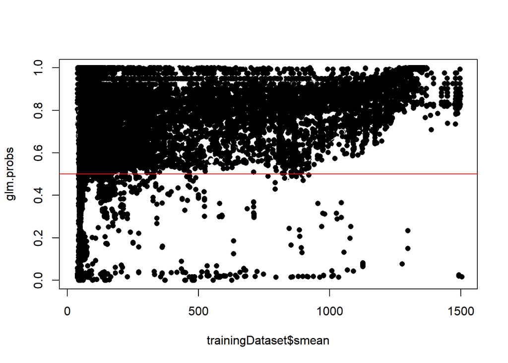

```r
plot(trainingDataset$smean, glm.probs, col = trainingDataset$label, pch = 16)
abline(h = 0.5, col = "red", lty = 1)
```

### Confusion matrix #1

```r
#Confusion matrix table
conf_matrix <- table(glm.pred, trainingDataset$label)
print(conf_matrix)
```

```
##
## glm.pred      0      1
##        0  36991   4828
##        1  19009 114513
```

True Positive (TP): The model correctly predicted 114,513 instances as class 1.

True Negative (TN): The model correctly predicted 36,991 instances as class 0.

# Second model

### Second model using rate + dpkts + spkts + sbytes + sinpkt + dbytes + sqrt(sload)+ sqrt(dur) + rate + state + service + smean

```r
# 2th logistic regression model
glm.fit <- glm(label ~ rate + dpkts +  spkts + sbytes + sinpkt + dbytes + sqrt(sload)+ sqrt(dur) + rate + state + service +  smean, data = trainingDataset, family = binomial)
glm.probs <- predict(glm.fit, trainingDataset, type = "response")

# Convert predicted probabilities to binary predictions (0 or 1)
glm.pred <- ifelse(glm.probs > 0.5, 1, 0)
```

### Predicted probabilities for the first 10

```r
# Display or use the predicted probabilities for the first 10 observations
print(glm.probs[1:10])
```

```
##         1         2         3         4         5         6         7         8
## 0.6795418 0.6931385 0.8198576 0.9290578 0.6695499 0.6562727 0.6618036 0.6427814
##         9        10
## 0.6463791 0.6284530
```

### Checking the accuracy of the model using the mean of the predictions

## Accuracy of 54.70%

```r
# Calculate accuracy (mean of correct predictions)
accuracy <- mean(glm.pred == testingDataset$label)
print(accuracy)
```

```
## [1] 0.5470198
```

### Ploting the model created in comparision with the smean of the data base.

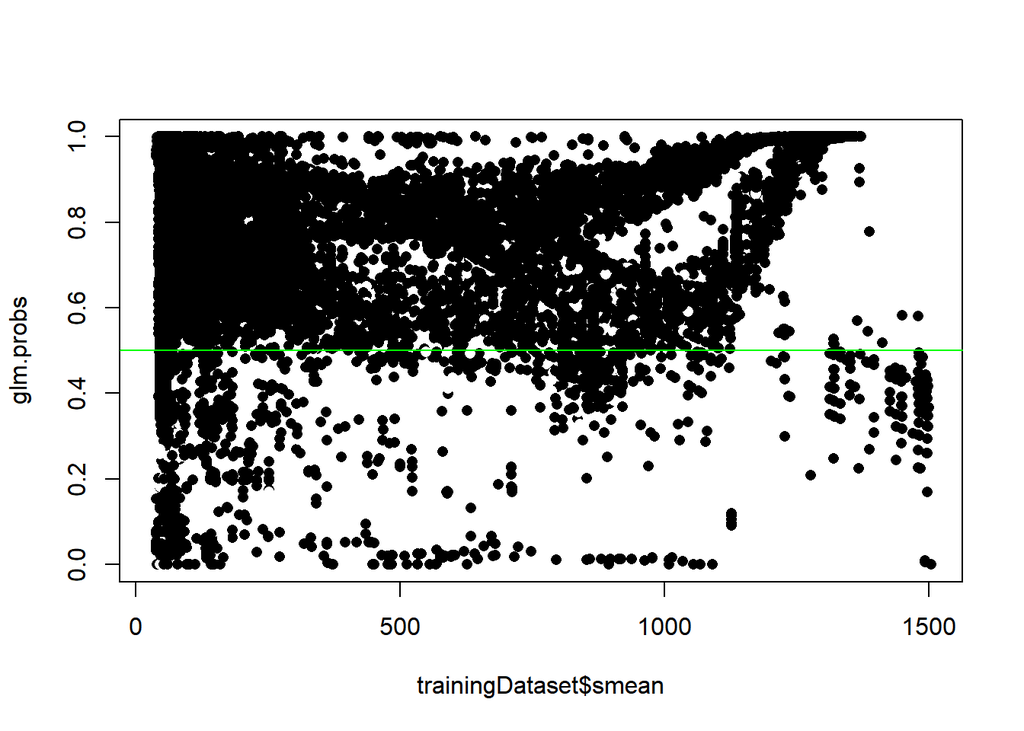

```r
plot(trainingDataset$smean, glm.probs, col = trainingDataset$label, pch = 16)
abline(h = 0.5, col = "green", lty = 1)
```

### Confusion matrix #2

```r
conf_matrix <- table(glm.pred, trainingDataset$label)
print(conf_matrix)
```

```
##
## glm.pred      0      1
##        0  40685   3648
##        1  15315 115693
```

True Positive (TP): The model correctly predicted 115,693 instances as class 1.